# Final Exam Summer 2025

270 points

Author

Esteban Montenegro-Montenegro

Published

June 17, 2025

## Description

In this exam, which is more like a practice exercise; you’ll have to solve several applied tasks. This means you’ll have to use `Jamovi` in some parts to analyze data sets. In other parts, you’ll need to answer theoretical questions based on the slides provided in class.

If you find a more creative way to answer an exercise please do it, don’t limit yourself! There are multiple ways to answer to a statistical dilemma, and your creativity is totally encouraged!

You may also use `R` to answer this “exam”.

## Part 1: Let’s check some important concepts

Please copy the question along with your answer in a Word document. You may also use `Quarto` to earn extra points. 4 points each question.

**Note**

You may watch this [video](https://youtu.be/QinDbZH6juQ) to complete the second part.

1. A true experiment selects participants randomly, and assign participants randomly to different conditions :

True  
False

2. Qualitative research collects numerical values to reject the null hypothesis :

True  
False

3. Mario needs to know if there is a causal relationship between sugar intake and high BMI (Body Mass Index). What type of design should Mario conduct?

Interview  
Experiment  
Qualitative design  
All the above are true

4. Select the option that will help you to collect counterfactual evidence in an experiment:

Control group  
Waiting list  
Recruit participants online  
Options 1 and 2 are correct

5. If you estimate a correlation between two variables, you can also assume causation:

True  
False

6. Write the three requirements of a causal relationship. [HINT: Check this lecture](https://m-square.net/lecture1/ResearchDesigns.html#/title-slide)
7. The following figure is an example of:

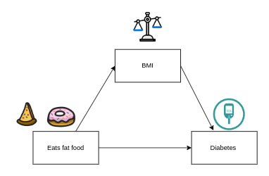

Error variance  
Moderation  
Correlation  
Mediation

8. In the lecture titled: [“Introduction to probability and statistics”](https://m-square.net/lecture3/introProbAndStats.html#/reality-nature-science-and-models-ii) , I showed the picture below. What is the meaning of this picture following slide 3 ?

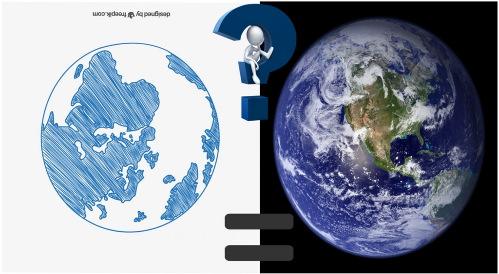

9. Select only the TRUE statement:

Models are perfect representations of Nature  
Data produces models  
Models produce data, data does not produce models  
All statistical models are perfectly correct

10. Parameters in a statistical model are unknown information, we collect data to reduce the uncertainty in the parameters:

True  
False

11. The following expression represents a probabilistic model: (25 points)

$$\begin{equation}
Y \sim p(y)
\end{equation}$$

True  
False

12. The reduction in uncertainty about model parameters that you achieve when you collect data is called statistical inference:

True  
False

13. The following histogram shows a continuous distribution:

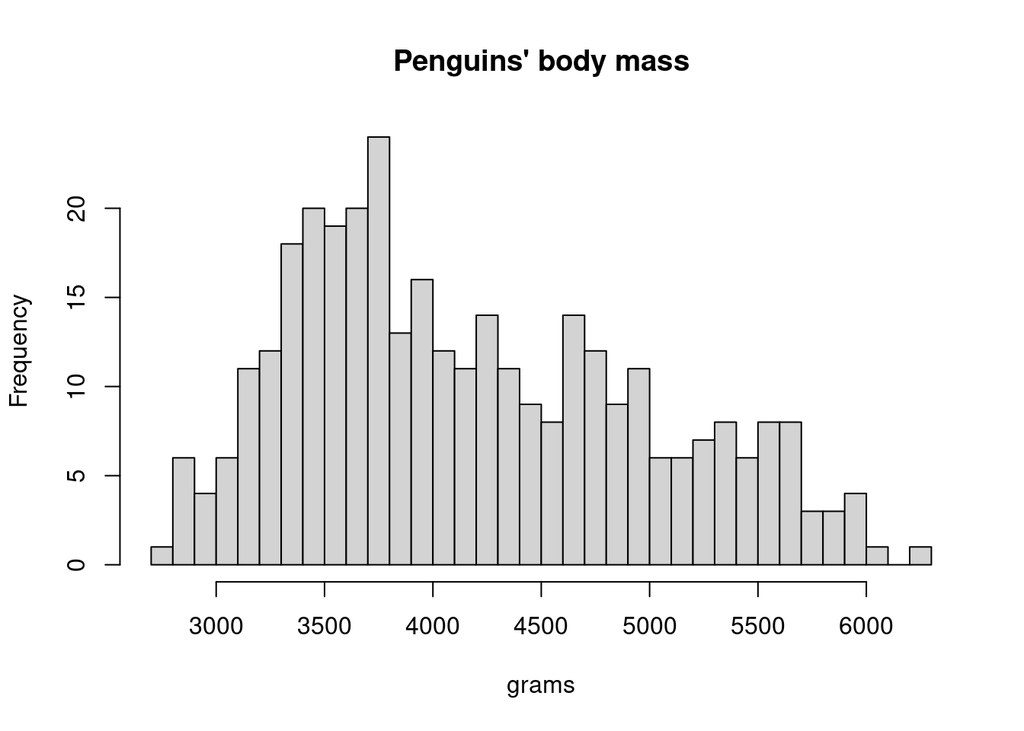

```r
library(palmerpenguins)
hist(penguins$body_mass_g,
     breaks = 50,
     main = "Penguins' body mass",
     xlab = "grams")
```

True  
False

14. Diane needs to estimate a Classical Regression Model. Diane believes that ethnicity has an effect on income. Diane asked for four ethnicity categories in her survey: white, black, Hispanic/Latino, and other. How many dummy coded variables does she need to compute to add ethnicity as a predictor of income?

Eleven  
Ten  
Three  
Diane does not need dummy coded variables in this case

15. We can consider t-test and the Classical Regression Model as part of the General Linear Model:

True  
False

16. In the following correlation matrix, is the correlation ($r$ = -0.053) between attention and rumZ explained by chance alone? (25 points)

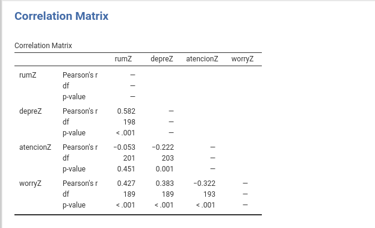

True  
False

17. What type of plot is the following example?

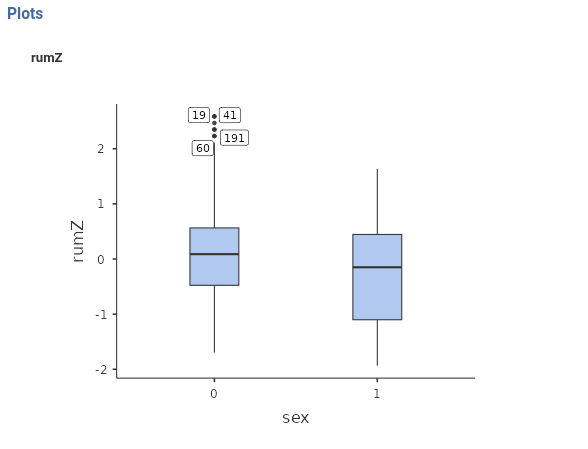

Histogram  
Box plot  
Probability Density Function  
Bar plot

18. According the following table, is the mean difference between groups explained by chance alone? If not, how do you know?

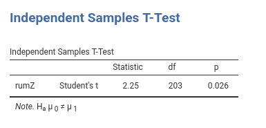

## Second Part: Hands on real data…as always.

In this second part, you may use `JAMOVi` or `R` to answer each question. I’ll provide data sets that you will open in `JAMOVI` or `R` to answer each question.

1. In this exercise we will estimate a One-way ANOVA. One-way means that we will use only one predictor or grouping variable to reject the null hypothesis. The data set that we will use is the data file named `ruminationClean.csv`. You may download the file from this link [CLICK HERE](https://mega.nz/file/yIllQKJD#jAYg2tdc9kkSi1KYtk0L5NGFeB2rpD0nOXkRDyn3SGk)

You can also copy the following code to open the file from my personal repository. This method doesn’t need to download any file. This method only works if you are using `R`:

```r
url <- "https://raw.githubusercontent.com/blackhill86/mm2/main/dataSets/ruminationClean.csv"
ruminate <- read.csv(url)
```

In our One-way ANOVA we will use the variable “Booklet” as our grouping variable. Booklet is a variable that has three numbers: 1,2 and 3. These numbers corresponds to different versions of the same survey, in each version the depression items were presented in different locations. In booklet 1, depression items were presented at the beginning of the survey, in booklet 2, depression items were presented in the middle of the survey, and finally in booklet 3, depression questions were presented at the end of the survey.

Why did I sort the depression items into three positions? This is appropriate when your survey is very long, and you believe people will be exhausted by the end of the survey. When participants are tired, they tend to give quick answers without thinking carefully. To avoid the effect of tiredness, you can create different versions of the same survey, assign the surveys randomly, and then analyze if there was an effect of tiredness in the depression score.

**Important**

I used the word “booklet” to name the column because this study was done long time ago. In that moment, online surveys were not often used in Costa Rica. Each participant had to answer a paper and pencil version of the survey.

Follow the next steps:

1. Open the file `ruminationClean.csv` in `JAMOVI`.
2. Click on *ANOVA* in the top bar.
3. Select “Booklet” variable as your grouping variable.
4. Select “depreZ” (depression) as your dependent variable.

After following the previous steps, answer the following questions:

1. What is the null hypothesis in this ANOVA analysis? (10 points)
2. Create a box plot of depreZ by Booklet interpret the plot (10points)

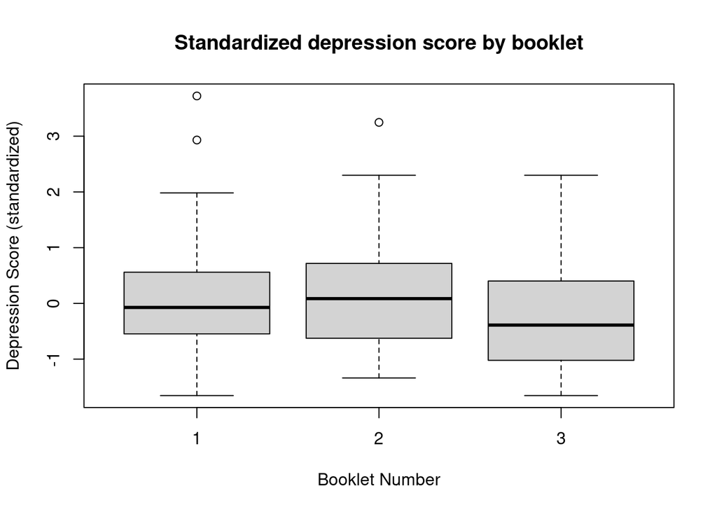

```r
boxplot(depreZ~ Booklet,
       data=ruminate,
      main="Standardized depression score by booklet",
      xlab="Booklet Number",
      ylab="Depression Score (standardized)")
```

2. Report and interpret the test of assumptions: [homogeneity of variance](https://m-square.net/lecture9/AssumptionsAndMore.html#/anova-and-classical-regression-model), [normality test](https://m-square.net/lecture9/AssumptionsAndMore.html#/anova-and-classical-regression-model-1), and [Q-Q plot](https://m-square.net/lecture9/AssumptionsAndMore.html#/classical-regression-model-normality-assumption-1). (40 points)
3. Report your [ANOVA](https://m-square.net/lecture9/AssumptionsAndMore.html#/f-ratio-estimation-lets-go-to-the-point) results in a table. (40 points)
4. Were the mean differences in depression by booklet version explained by chance? (38 points)
5. Perform a post-hoc analysis to determine which means were different beyond chance. (38 points). Copy and paste the table in this answer.
6. What is the implication of the result? Was the depression score different depending on the presentation order of the items? (22 points)